# Guide to Knitting PDF’s with RMarkdown

Ross

2018-07-02

# Spacing, Page Breaks, Formatting

In general the document with format each object chronologically. But some chuck options will modify the placement of an plot, table or image.

> Bottom line: Markdown is not LaTeX. It was designed for HTML instead of LaTeX.

(Yihui Xie Explaining Markdown, Pandoc,formattting power on SO )[https://stackoverflow.com/a/17648350/9115822]

## Main lesson

Using captions (`fig.cap`) treats plots, table or images differently and by default places one per page.

See `ex_breaks.pdf` and `ex_no_breaks.pdf` to see the difference.

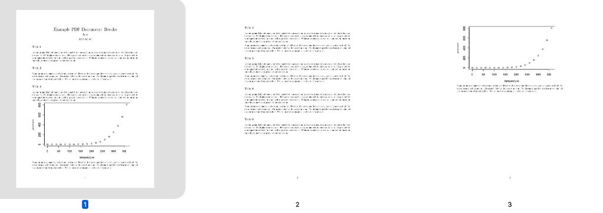

Example of chronologically

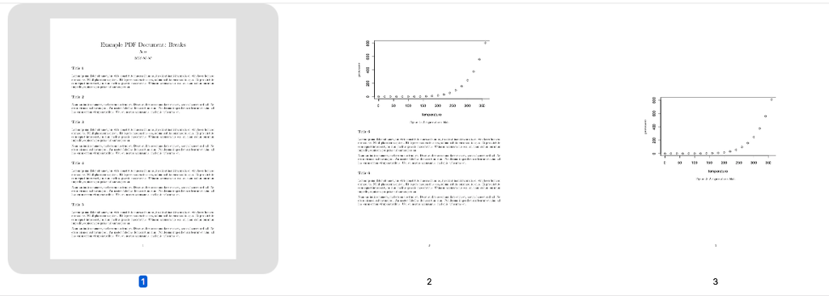

Example of Captioned

## Sidenote

There are options to set behaviour but they don’t work very well, as they dont seem to be strict.

```
knitr::opts_chunk$set(fig.pos = "t")
```

Where:

> h , here; t , top; b , bottom; p , page of float

# Table of Contents

```
---
title: "Example PDF Document"
author: "Ross"
date: "2018-07-02"
output:
  pdf_document:
    toc: true
    toc_depth: 2
---
```

# Margin Control

Latex/Pandoc commands can be used in the first layer of the `yaml`. (First layer meaning the same indentation as `title`, `date`, etc.)

```
---
title: "Example PDF Document"
author: "Ross"
date: "2018-07-02"
geometry: margin=1.2in
---
```

# Typeface / Font

This is a tricky one because there isn’t `R` and `RMarkdown` specific functions to modify the font…

All indications are that you have to use LaTeX.

```
\renewcommand{\familydefault}{\rmdefault}
```

(Some possibilities)[https://www.sharelatex.com/learn/Font_sizes,_families,_and_styles#Font_families]

# Footnotes

Easy, using `[^1]` and a connected `[^1]: blah`:

```
Utinam accusata no sea, an nam solum omnium impedit, equidem propriae urbanitas per an. [^1]

[^1]: Lorem ipsum dolor sit amet, ius viris constituto mnesarchum ea, ius dicat inani iracundia ei, vim facer homero eirmod te. Nihil phaedrum qui eu.
```

# Bibliographies and Citations

There are a bunch of ways to do this. I have included in `ex_main.Rmd` and example of a internal `yaml` reference, with citation and Bibliography at the end. A bit of a LaTeX learning curve.

### A Reference

```
title: "Example PDF Document"
author: "Ross"
date: "2018-07-02"
references:
- id: fenner2012a
  title: One-click science marketing
  author:
  - family: Fenner
    given: Martin
  container-title: Nature Materials
  volume: 11
  URL: 'http://dx.doi.org/10.1038/nmat3283'
  DOI: 10.1038/nmat3283
  issue: 4
  publisher: Nature Publishing Group
  page: 261-263
  type: article-journal
  issued:
    year: 2012
    month: 3
```

### A Citation

```
[@fenner2012a]
```

### Automatically getting an attached bibliography at the end of document

```
# References
```

# Page Numbers

By default a `RMarkdown` using the `pdf_document` output with have page numbers. Controlled in `yaml` with LaTeX command:

```
title: "Example PDF Document"
author: "Ross"
date: "2018-07-02"
header-includes:
  \pagenumbering{gobble}
```

# Tables

If the data is in a `data.frame`, `df` or `tibble` class object then we can just `print()` the data to get a table.

Using the `kable()` function neatens it up with cell borders etc.

```r
kableExtra::kable(head(iris))
```

Captioning a table, changes the formatting (centres and puts at bottom of page). See `ex_table.pdf`

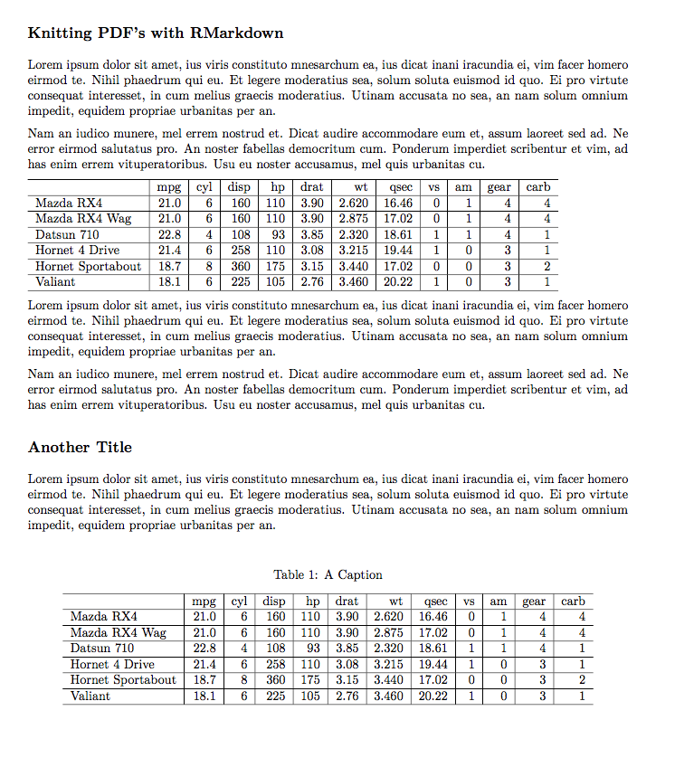

Example of Tables